# Multi-Week Assignment#1 Part 2 - Polynomial, Decision Tree, Random Forest Regression & Model Selection0305

## MSCA 37014 Python for Analytics

### Assignment#1 Supervised Learning Regression (170 points + 20 bonus points)

### Exploratory Data Analysis, Data Preprocessing, Simple and Multiple Linear Regression Model

### Part 1 Due Date: 3/4/2021

### Part 2 Due Date: 3/7/2021 (Please see the questions in the second part of this notebook)

Please submit your assignment solutions in **PDF** or **HTML** file; **Submitted Jupyter Notebook will not be graded**

## Part 1 (125 points + 10 bonus points)

### Section 1 - Exploratory Data Analysis and Data Visualization (45 points + 10 bonus points)

#### 8. Create some simple and quick plots with all the feature (hint: pairplot()) (5 points)

#### 9. Create additional plots which could discover and support the key data findings for Part 1 (5 bonus points)

#### 10. Make a Data Summary from Exploratory Data Analysis and Data Visualization for Part 1 (5 points + 5 bonus points)

- 1) What are the features which are highly correlated to the target variable (MEDV)? (5 points)
- 2) What additional data insights you think are valuable to share.(5 bonus points)

### Section 2 - Simple Linear Regression (only use one feature having the highest correlation coefficient with the target variable) (45 points)

#### 1. Split the dataset into X, y, Training set, and Test set (only the highly correlated feature in X) (5 points)

#### 2. Train the Simple Linear Regression model on the Training set (10 points)

#### 3. Predict and visualize the test set results (10 points)

#### 4. Visualize the training set results (5 points)

#### 5. Make a single prediction (5 points)

#### 6. Get the final linear regression equation (with values of the coefficients) (10 points)

### Section 3 - Multiple Linear Regression (35 points)

#### 1. Split the dataset into X, y, Training set, and Test set (more than one feature in X) (5 points)

#### 2. Train the Multiple Linear Regression model on the Training set (10 points)

#### 3. Predict the test set results (5 points)

#### 4. Make a single prediction (5 points)

#### 5. Get the final linear regression equation (with values of the coefficients) (10 points)

## Part 2 (45 points + 10 bonus points)

### Section 4 - Polynomial Linear Regression (15 points)

#### 1. Split the dataset into X, y, Training set, and Test set (exam and pick more than one feature or one strong feature in X based on the non-linear relationship with the target variable from data visualization) - similar as Section 3

#### 2. Train the Polynomial Linear Regression model on the Training set (10 points)

#### 3. Get the final linear regression equation (with values of the coefficients) (5 points)

### Section 5 - Decision Tree Regression (10 points)

#### 1. Split the dataset into X, y, Training set, and Test set (more than one feature in X) - same as Section 3

#### 2. Train the Decision Tree Regression model on the Training set (10 points)

### Section 6 - Random Forest Regression (10 points)

#### 1. Split the dataset into X, y, Training set, and Test set (more than one feature in X) - same as Section 3

#### 2. Train the Random Forest Regression model on the Training set (10 points)

### Section 7 - Calculate R Square for all 5 Regression models to Select the Best model (10 points)

- Any additional model evaluation metrics you think it would be good to use for all 5 Regression models (10 bonus points)

### Boston Data Description

- The medv variable is the **target variable**.
- The Boston data frame has 506 rows and 13 columns.
- This data frame contains the following columns:

`crim`: per capita crime rate by town.

`zn`: proportion of residential land zoned for lots over 25,000 sq.ft.

`indus`: proportion of non-retail business acres per town.

`chas`: Charles River dummy variable (= 1 if tract bounds river; 0 otherwise).

`nox`: nitrogen oxides concentration (parts per 10 million).

`rm`: average number of rooms per dwelling.

`age`: proportion of owner-occupied units built prior to 1940.

`dis`: weighted mean of distances to five Boston employment centres.

`rad`: index of accessibility to radial highways.

`tax`: full-value property-tax rate per \$10,000.

`ptratio`: pupil-teacher ratio by town.

`lstat`: lower status of the population (percent).

`medv`: median value of owner-occupied homes in \$1000s.

#### Source

Harrison, D. and Rubinfeld, D.L. (1978) Hedonic prices and the demand for clean air. J. Environ. Economics and Management 5, 81–102.

Belsley D.A., Kuh, E. and Welsch, R.E. (1980) Regression Diagnostics. Identifying Influential Data and Sources of Collinearity. New York: Wiley.

# Part 1

## Section 1 - Exploratory Data Analysis and Data Visualization

### 1. Import Libraries and oad the data into the pandas data frame

```python
# Student's Answer:
%matplotlib inline
import numpy as np
import matplotlib.pyplot as plt
import pandas as pd
import seaborn as sns
```

### 2. Review data dimension and data type for each feature

```python
# Student's Answer:
# Student's Answer:
dataset = pd.read_csv('BostonHousingData.csv', sep=',')
dataset.info()
```

```
<class 'pandas.core.frame.DataFrame'>
RangeIndex: 506 entries, 0 to 505
Data columns (total 13 columns):
 #   Column   Non-Null Count  Dtype
---  ------   --------------  -----
 0   CRIM     506 non-null    float64
 1   ZN       506 non-null    float64
 2   INDUS    506 non-null    float64
 3   CHAS     506 non-null    int64
 4   NOX      506 non-null    float64
 5   RM       506 non-null    float64
 6   AGE      506 non-null    float64
 7   DIS      506 non-null    float64
 8   RAD      506 non-null    int64
 9   TAX      506 non-null    int64
 10  PTRATIO  506 non-null    float64
 11  LSTAT    506 non-null    float64
 12  MEDV     506 non-null    float64
dtypes: float64(10), int64(3)
memory usage: 51.5 KB
```

### 3. Identify the unique number of values of each feature in the dataset

```python
# Student's Answer:
dataset['CRIM'].value_counts()
```

```
14.33370    2
0.01501     2
0.08265     1
1.35472     1
0.03615     1
           ..
0.11460     1
0.03237     1
5.82115     1
0.02187     1
0.03578     1
Name: CRIM, Length: 504, dtype: int64
```

```python
dataset['ZN'].value_counts()
```

```
0.0      372
20.0      21
80.0      15
12.5      10
22.0      10
25.0      10
40.0       7
45.0       6
30.0       6
90.0       5
21.0       4
95.0       4
60.0       4
33.0       4
75.0       3
35.0       3
28.0       3
55.0       3
52.5       3
70.0       3
34.0       3
85.0       2
82.5       2
17.5       1
100.0      1
18.0       1
Name: ZN, dtype: int64
```

```python
dataset['INDUS'].value_counts()
```

```
18.10    132
19.58     30
8.14      22
6.20      18
21.89     15
        ...
1.21       1
4.15       1
2.02       1
2.01       1
4.00       1
Name: INDUS, Length: 76, dtype: int64
```

```python
dataset['CHAS'].value_counts()
```

```
0    471
1     35
Name: CHAS, dtype: int64
```

```python
dataset['NOX'].value_counts()
```

```
0.538    23
0.713    18
0.437    17
0.871    16
0.624    15
         ..
0.435     1
0.422     1
0.518     1
0.385     1
0.389     1
Name: NOX, Length: 81, dtype: int64
```

```python
dataset['RM'].value_counts()
```

```
6.405    3
5.713    3
6.167    3
6.127    3
6.229    3
        ..
6.701    1
6.232    1
6.593    1
6.800    1
6.625    1
Name: RM, Length: 446, dtype: int64
```

```python
dataset['AGE'].value_counts()
```

```
100.0    43
96.0      4
98.2      4
95.4      4
97.9      4
         ..
47.6      1
92.7      1
13.9      1
58.4      1
40.1      1
Name: AGE, Length: 356, dtype: int64
```

```python
dataset['DIS'].value_counts()
```

```
3.4952    5
5.2873    4
5.4007    4
5.7209    4
6.8147    4
         ..
1.7659    1
4.4534    1
2.1000    1
4.0905    1
1.8125    1
Name: DIS, Length: 412, dtype: int64
```

```python
dataset['RAD'].value_counts()
```

```
24    132
5     115
4     110
3      38
6      26
8      24
2      24
1      20
7      17
Name: RAD, dtype: int64
```

```python
dataset['TAX'].value_counts()
```

```
666    132
307     40
403     30
437     15
304     14
      ...
280      1
313      1
351      1
422      1
285      1
Name: TAX, Length: 66, dtype: int64
```

```python
dataset['PTRATIO'].value_counts()
```

```
20.2    140
14.7     34
21.0     27
17.8     23
19.2     19
17.4     18
18.6     17
19.1     17
16.6     16
18.4     16
21.2     15
15.2     13
13.0     12
20.9     11
17.9     11
18.7      9
19.7      8
19.6      8
17.6      7
16.4      6
18.0      5
16.0      5
20.1      5
16.1      5
16.9      5
16.8      4
14.9      4
19.0      4
18.5      4
17.0      4
18.2      4
18.3      4
12.6      3
14.8      3
18.9      3
15.3      3
15.9      2
22.0      2
15.6      2
18.8      2
15.5      1
17.3      1
15.1      1
21.1      1
13.6      1
14.4      1
Name: PTRATIO, dtype: int64
```

```python
dataset['LSTAT'].value_counts()
```

```
14.10    3
6.36     3
18.13    3
8.05     3
7.79     3
        ..
9.69     1
9.62     1
5.64     1
22.98    1
29.05    1
Name: LSTAT, Length: 455, dtype: int64
```

```python
dataset['MEDV'].value_counts()
```

```
50.0    16
25.0     8
23.1     7
21.7     7
22.0     7
        ..
12.8     1
29.9     1
9.6      1
36.1     1
13.0     1
Name: MEDV, Length: 229, dtype: int64
```

### 4. Check for missing values

```python
# Student's Answer:
dataset.isna().sum()
```

```
CRIM       0
ZN         0
INDUS      0
CHAS       0
NOX        0
RM         0
AGE        0
DIS        0
RAD        0
TAX        0
PTRATIO    0
LSTAT      0
MEDV       0
dtype: int64
```

### 5. Review the data summary statistics

```python
# Student's Answer:
dataset.describe()
```

|  | CRIM | ZN | INDUS | CHAS | NOX | RM | AGE | DIS | RAD | TAX | PTRATIO | LSTAT | MEDV |
| --- | --- | --- | --- | --- | --- | --- | --- | --- | --- | --- | --- | --- | --- |
| count | 506.000000 | 506.000000 | 506.000000 | 506.000000 | 506.000000 | 506.000000 | 506.000000 | 506.000000 | 506.000000 | 506.000000 | 506.000000 | 506.000000 | 506.000000 |
| mean | 3.613524 | 11.363636 | 11.136779 | 0.069170 | 0.554695 | 6.284634 | 68.574901 | 3.795043 | 9.549407 | 408.237154 | 18.455534 | 12.653063 | 22.532806 |
| std | 8.601545 | 23.322453 | 6.860353 | 0.253994 | 0.115878 | 0.702617 | 28.148861 | 2.105710 | 8.707259 | 168.537116 | 2.164946 | 7.141062 | 9.197104 |
| min | 0.006320 | 0.000000 | 0.460000 | 0.000000 | 0.385000 | 3.561000 | 2.900000 | 1.129600 | 1.000000 | 187.000000 | 12.600000 | 1.730000 | 5.000000 |
| 25% | 0.082045 | 0.000000 | 5.190000 | 0.000000 | 0.449000 | 5.885500 | 45.025000 | 2.100175 | 4.000000 | 279.000000 | 17.400000 | 6.950000 | 17.025000 |
| 50% | 0.256510 | 0.000000 | 9.690000 | 0.000000 | 0.538000 | 6.208500 | 77.500000 | 3.207450 | 5.000000 | 330.000000 | 19.050000 | 11.360000 | 21.200000 |
| 75% | 3.677082 | 12.500000 | 18.100000 | 0.000000 | 0.624000 | 6.623500 | 94.075000 | 5.188425 | 24.000000 | 666.000000 | 20.200000 | 16.955000 | 25.000000 |
| max | 88.976200 | 100.000000 | 27.740000 | 1.000000 | 0.871000 | 8.780000 | 100.000000 | 12.126500 | 24.000000 | 711.000000 | 22.000000 | 37.970000 | 50.000000 |

### 6. Create a correlation table with all the numeric features

```python
# Student's Answer:
dataset.corr()
```

|  | CRIM | ZN | INDUS | CHAS | NOX | RM | AGE | DIS | RAD | TAX | PTRATIO | LSTAT | MEDV |
| --- | --- | --- | --- | --- | --- | --- | --- | --- | --- | --- | --- | --- | --- |
| CRIM | 1.000000 | -0.200469 | 0.406583 | -0.055892 | 0.420972 | -0.219247 | 0.352734 | -0.379670 | 0.625505 | 0.582764 | 0.289946 | 0.455621 | -0.388305 |
| ZN | -0.200469 | 1.000000 | -0.533828 | -0.042697 | -0.516604 | 0.311991 | -0.569537 | 0.664408 | -0.311948 | -0.314563 | -0.391679 | -0.412995 | 0.360445 |
| INDUS | 0.406583 | -0.533828 | 1.000000 | 0.062938 | 0.763651 | -0.391676 | 0.644779 | -0.708027 | 0.595129 | 0.720760 | 0.383248 | 0.603800 | -0.483725 |
| CHAS | -0.055892 | -0.042697 | 0.062938 | 1.000000 | 0.091203 | 0.091251 | 0.086518 | -0.099176 | -0.007368 | -0.035587 | -0.121515 | -0.053929 | 0.175260 |
| NOX | 0.420972 | -0.516604 | 0.763651 | 0.091203 | 1.000000 | -0.302188 | 0.731470 | -0.769230 | 0.611441 | 0.668023 | 0.188933 | 0.590879 | -0.427321 |
| RM | -0.219247 | 0.311991 | -0.391676 | 0.091251 | -0.302188 | 1.000000 | -0.240265 | 0.205246 | -0.209847 | -0.292048 | -0.355501 | -0.613808 | 0.695360 |
| AGE | 0.352734 | -0.569537 | 0.644779 | 0.086518 | 0.731470 | -0.240265 | 1.000000 | -0.747881 | 0.456022 | 0.506456 | 0.261515 | 0.602339 | -0.376955 |
| DIS | -0.379670 | 0.664408 | -0.708027 | -0.099176 | -0.769230 | 0.205246 | -0.747881 | 1.000000 | -0.494588 | -0.534432 | -0.232471 | -0.496996 | 0.249929 |
| RAD | 0.625505 | -0.311948 | 0.595129 | -0.007368 | 0.611441 | -0.209847 | 0.456022 | -0.494588 | 1.000000 | 0.910228 | 0.464741 | 0.488676 | -0.381626 |
| TAX | 0.582764 | -0.314563 | 0.720760 | -0.035587 | 0.668023 | -0.292048 | 0.506456 | -0.534432 | 0.910228 | 1.000000 | 0.460853 | 0.543993 | -0.468536 |
| PTRATIO | 0.289946 | -0.391679 | 0.383248 | -0.121515 | 0.188933 | -0.355501 | 0.261515 | -0.232471 | 0.464741 | 0.460853 | 1.000000 | 0.374044 | -0.507787 |
| LSTAT | 0.455621 | -0.412995 | 0.603800 | -0.053929 | 0.590879 | -0.613808 | 0.602339 | -0.496996 | 0.488676 | 0.543993 | 0.374044 | 1.000000 | -0.737663 |
| MEDV | -0.388305 | 0.360445 | -0.483725 | 0.175260 | -0.427321 | 0.695360 | -0.376955 | 0.249929 | -0.381626 | -0.468536 | -0.507787 | -0.737663 | 1.000000 |

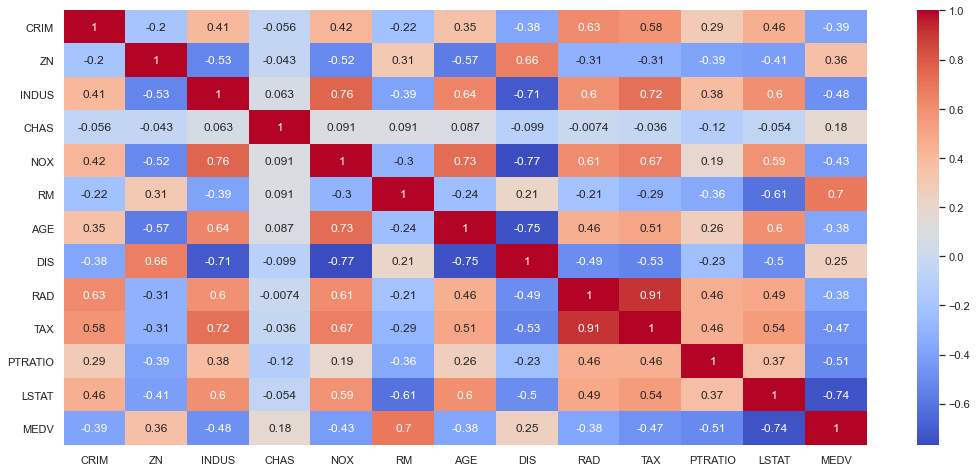

```python
# Student's Answer:
sns.set(rc={'figure.figsize':(18,8)})
sns.heatmap(dataset.corr(),cmap='coolwarm',annot=True)
plt.show()
```

### 8. Create some simple and quick plots with all the feature (hint: `pairplot()`)

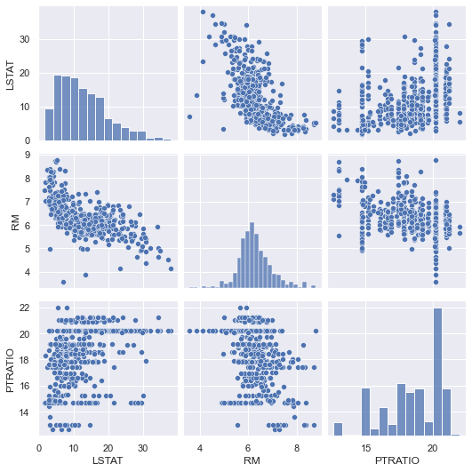

```python
# Student's Answer:
sns.pairplot(dataset[['LSTAT','RM','PTRATIO']])
plt.show()
```

### 9. Create additional plots which could discover and support the key data findings for Part 1

```python
dataset.info()
```

```
<class 'pandas.core.frame.DataFrame'>
RangeIndex: 506 entries, 0 to 505
Data columns (total 13 columns):
 #   Column   Non-Null Count  Dtype
---  ------   --------------  -----
 0   CRIM     506 non-null    float64
 1   ZN       506 non-null    float64
 2   INDUS    506 non-null    float64
 3   CHAS     506 non-null    int64
 4   NOX      506 non-null    float64
 5   RM       506 non-null    float64
 6   AGE      506 non-null    float64
 7   DIS      506 non-null    float64
 8   RAD      506 non-null    int64
 9   TAX      506 non-null    int64
 10  PTRATIO  506 non-null    float64
 11  LSTAT    506 non-null    float64
 12  MEDV     506 non-null    float64
dtypes: float64(10), int64(3)
memory usage: 51.5 KB
```

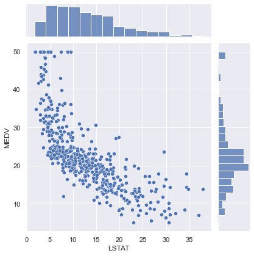

```python
sns.jointplot(x='LSTAT',y='MEDV',data=dataset,kind='scatter')
plt.show()
```

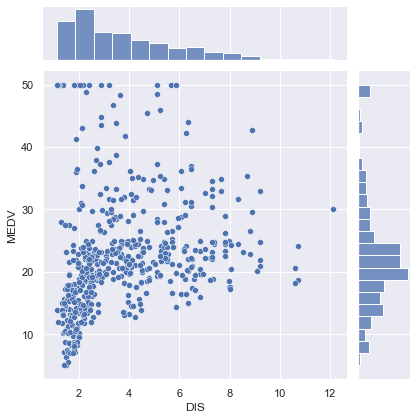

```python
sns.jointplot(x='DIS',y='MEDV',data=dataset,kind='scatter')
plt.show()
```

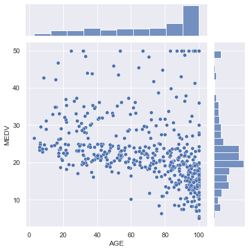

```python
sns.jointplot(x='AGE',y='MEDV',data=dataset,kind='scatter')
plt.show()
```

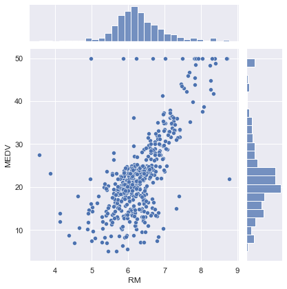

```python
sns.jointplot(x='RM',y='MEDV',data=dataset,kind='scatter')
plt.show()
```

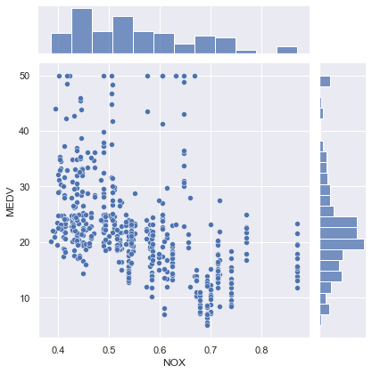

```python
sns.jointplot(x='NOX',y='MEDV',data=dataset,kind='scatter')
plt.show()
```

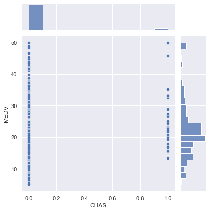

```python
sns.jointplot(x='CHAS',y='MEDV',data=dataset,kind='scatter')
plt.show()
```

### 10. Make a Data Summary from Exploratory Data Analysis and Data Visualization

- 1) What are the features which are highly correlated to the target variable (MEDV)? (5 points)
- 2) What additional data insights you think are valuable to share.(5 bonus points)

```python
# Student's Answer:

## 1 -  LSTAT, RM, PTRATIO  - Correlation greater than 0.5
```

```python
## 2 -  Column CHAS very low correlation so taking it out to reduce noise
```

```python
clean_dataset = dataset
clean_dataset_poly = dataset
clean_dataset_d_tree = dataset
clean_dataset_r_forest = dataset
```

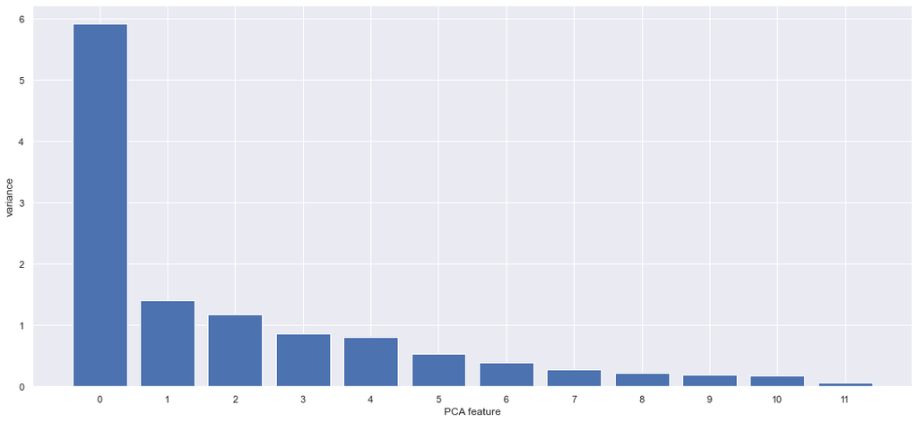

```python
from sklearn.decomposition import PCA
from sklearn.preprocessing import StandardScaler
from sklearn.pipeline import make_pipeline
import matplotlib.pyplot as plt

# Create scaler: scaler
scaler = StandardScaler()

# Create a PCA instance: pca
pca = PCA()

# Create pipeline: pipeline
pipeline = make_pipeline(scaler, pca)

# Fit the pipeline to 'samples'
pipeline.fit(dataset.drop(['MEDV'], axis=1))

# Plot the explained variances
features = range(pca.n_components_)
plt.bar(features, pca.explained_variance_)
plt.xlabel('PCA feature')
plt.ylabel('variance')
plt.xticks(features)
plt.show()
```

## Section 2 - Simple Linear Regression (use the feature having the highest correlation coefficient with the target variable)

### 1. Split the dataset into X, y, Training set, and Test set (ony one feature in X)

```python
# Student's Answer:
#X = dataset.iloc[:, 11].values
#y = dataset.iloc[:, -1].values

X = dataset['LSTAT'].values.reshape(-1, 1)
y = dataset['MEDV'].values
```

```python
from sklearn.model_selection import train_test_split
X_train, X_test, y_train, y_test = train_test_split(X, y, test_size=0.2, random_state=101)
```

### 2. Train the Simple Linear Regression model on the Training set

```python
# Student's Answer:
from sklearn.linear_model import LinearRegression
lm = LinearRegression()
lm.fit(X_train,y_train)
```

```
LinearRegression()
```

### 3. Predict and visualize the test set results

```python
# Student's Answer:
linear_predictions = lm.predict(X_test)
```

```
MAE: 5.347293504416108
MSE: 53.98802017490144
RMSE: 7.347654059283238
```

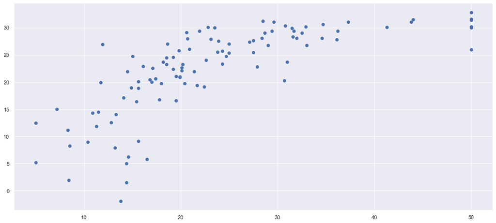

```python
plt.scatter(y_test,linear_predictions)
from sklearn import metrics
print('MAE:', metrics.mean_absolute_error(y_test, linear_predictions))
print('MSE:', metrics.mean_squared_error(y_test, linear_predictions))
print('RMSE:', np.sqrt(metrics.mean_squared_error(y_test, linear_predictions)))
```

```python
from sklearn.metrics import r2_score
r2_score(y_test, linear_predictions)
```

```
0.518785592947577
```

### 4. Visualize the training set results

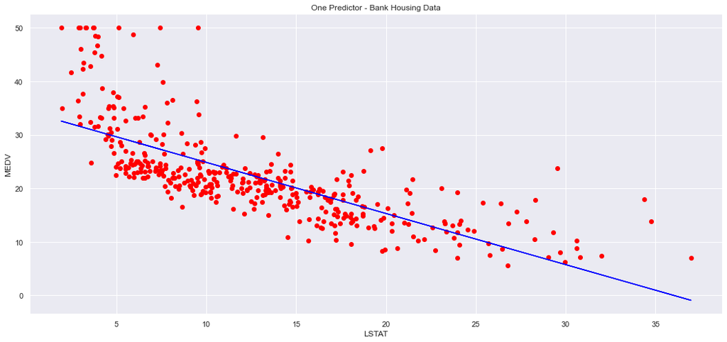

```python
plt.scatter(X_train, y_train, color = 'red')
plt.plot(X_train, lm.predict(X_train), color = 'blue')
plt.title('One Predictor - Bank Housing Data')
plt.xlabel('LSTAT')
plt.ylabel('MEDV')
plt.show()
```

### 5. Make a single prediction

```python
# Student's Answer:
pred_data = [0.21124, 12.5, 7.87, 0.524, 5.631, 100, 6.0821, 5, 311, 15.2, 29.93]
pred_data = np.array(pred_data).reshape(-1,1)
```

```python
print(lm.predict(pred_data))
```

```
[  34.19   22.46   26.88   33.9    29.02  -61.07   28.59   29.62 -262.51
   19.88    5.82]
```

### 6. Get the final linear regression equation (with values of the coefficients)

```python
print(lm.coef_)
```

```
[-0.95]
```

```python
print(lm.intercept_)
```

```
34.39600716924934
```

```python
from sklearn.metrics import r2_score
r2_score(y_test, linear_predictions)
```

```
0.518785592947577
```

# Student's Answer:

###### MEDV = 34 + -0.95xLSTAT

## Section 3 - Multiple Linear Regression

### 1. Split the dataset into X, y, Training set, and Test set (more than one feature in X)

```python
# Student's Answer:
clean_dataset = clean_dataset.drop(['CHAS'], axis=1)
X,y = clean_dataset.drop(['MEDV'], axis=1).values, dataset['MEDV'].values

from sklearn.model_selection import train_test_split
X_train, X_test, y_train, y_test = train_test_split(X, y, test_size=0.3, random_state=101)
```

### 2. Train the Multiple Linear Regression model on the Training set

```python
# Student's Answer:
from sklearn.linear_model import LinearRegression
lm = LinearRegression()
lm.fit(X_train,y_train)
```

```
LinearRegression()
```

### 3. Predict the test set results

```python
# Student's Answer:
mul_linear_predictions = lm.predict(X_test)
```

```
MAE: 3.8617968250202295
MSE: 29.03744662042926
RMSE: 5.388640516904914
```

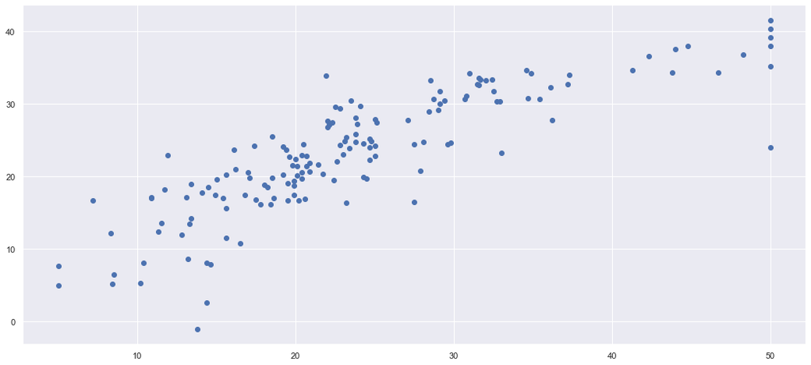

```python
plt.scatter(y_test,mul_linear_predictions)
from sklearn import metrics
print('MAE:', metrics.mean_absolute_error(y_test, mul_linear_predictions))
print('MSE:', metrics.mean_squared_error(y_test, mul_linear_predictions))
print('RMSE:', np.sqrt(metrics.mean_squared_error(y_test, mul_linear_predictions)))
```

### 4. Make a single prediction

```python
# Student's Answer:
print(lm.predict([[0.21124, 12.5, 7.87, 0.524, 5.631, 100, 6.0821, 5, 311, 15.2, 29.93]]))
```

```
[10.69]
```

```python
#Coefficient
print(lm.coef_)
```

```
[-1.02e-01  4.83e-02  4.78e-02 -1.85e+01  3.19e+00  2.02e-02 -1.40e+00
  2.78e-01 -1.22e-02 -1.01e+00 -6.40e-01]
```

```python
#Intercept
print(lm.intercept_)
```

```
44.97490739924778
```

```python
from sklearn.metrics import r2_score
r2_score(y_test, mul_linear_predictions)
```

```
0.7074612076225244
```

### 5. Get the final linear regression equation (with values of the coefficients)

# Part 2

## Section 4 - Polynomial Linear Regression

### 1. Split the dataset into X, y, Training set, and Test set (exam and pick more than one feature or one strong feature in X based on the non-linear relationship with the target variable from data visualization) - similar as Section 3

### 2. Train the Polynomial Linear Regression model on the Training set

```python
# Student's Answer:
#clean_dataset_poly = clean_dataset_poly.drop(['CHAS'], axis=1)
X = clean_dataset_poly[['LSTAT']].values
y = clean_dataset_poly[['MEDV']].values

from sklearn.model_selection import train_test_split
X_train, X_test, y_train, y_test = train_test_split(X, y, test_size=0.3, random_state=101)
```

```python
from sklearn.preprocessing import PolynomialFeatures
from sklearn.linear_model import LinearRegression

poly_reg = PolynomialFeatures(degree = 2)
X_poly = poly_reg.fit_transform(X_train)

Polyregressor = LinearRegression()
Polyregressor.fit(X_poly, y_train)
```

```
LinearRegression()
```

```python
polyy_pred = Polyregressor.predict(poly_reg.transform(X_test))
np.set_printoptions(precision=2)
#polyy_pred.reshape(len(polyy_pred),1)
```

```python
#Coefficient
print(Polyregressor.coef_)
```

```
[[ 0.   -2.25  0.04]]
```

```python
#Intercept
print(Polyregressor.intercept_)
```

```
[42.26]
```

```python
from sklearn.metrics import r2_score
PL_r2=r2_score(y_test, polyy_pred)
PL_r2
```

```
0.6315272294472266
```

### 3. Get the final linear regression equation (with values of the coefficients)

### Student's Answer:

###### MEDV = 42 + -2.25x+ 0.04x^2

## Section 5 - Decision Tree Regression

### 1. Split the dataset into X, y, Training set, and Test set (more than one feature in X) - same as Section 3

```python
# Student's Answer:
X,y = clean_dataset_d_tree.drop(['MEDV'], axis=1).values, dataset['MEDV'].values

from sklearn.model_selection import train_test_split
X_train, X_test, y_train, y_test = train_test_split(X, y, test_size=0.3, random_state=101)
```

### 2. Train the Decision Tree Regression model on the Training set

```python
# Student's Answer:
from sklearn.tree import DecisionTreeRegressor
dsregressor = DecisionTreeRegressor(random_state = 0)
dsregressor.fit(X_train, y_train)
```

```
DecisionTreeRegressor(random_state=0)
```

```python
dsy_pred = dsregressor.predict(X_test)
np.set_printoptions(precision=2)
print(np.concatenate((dsy_pred.reshape(len(dsy_pred),1), y_test.reshape(len(y_test),1)),1))
```

```
[[50.  50. ]
 [33.4 36.2]
 [12.7 11.7]
 [13.8 14.9]
 [29.8 30.8]
 [33.4 36.1]
 [42.8 50. ]
 [19.9 13.2]
 [26.7 41.3]
 [ 5.6  8.5]
 [29.8 23.5]
 [13.8 13.3]
 [19.3 20.2]
 [21.9 18.6]
 [22.8 18.5]
 [23.1 27.9]
 [ 7.5 10.4]
 [33.4 28.5]
 [26.6 28.4]
 [21.4 23.1]
 [ 8.8 12.8]
 [23.1 21.7]
 [20.6 11.9]
 [34.9 29.6]
 [33.2 37.3]
 [20.8 19.9]
 [30.1 29. ]
 [19.4 18. ]
 [50.  50. ]
 [33.3 34.6]
 [21.1 24.3]
 [18.6 18.2]
 [43.5 44. ]
 [45.4 50. ]
 [27.5 30.7]
 [21.7 22.6]
 [16.7 14.1]
 [23.  14.5]
 [ 7.4  8.4]
 [36.2 32.5]
```

[output cut: 97 more lines]

```
 [20.1 22. ]
 [39.8 46.7]
 [20.6 20.4]
 [11.8 13.4]
 [43.5 42.3]
 [23.6 37.2]
 [19.4 18.4]
 [27.9 24.8]
 [23.1 19.9]
 [23.1 20.4]
 [21.4 28.1]
 [22.5 20.7]
 [22.9 29.1]
 [16.6 17.5]
 [16.7 23.2]]
```

```python
from sklearn.metrics import r2_score
DS_r2=r2_score(y_test, dsy_pred)
DS_r2
```

```
0.7941600030572449
```

## Section 6 - Random Forest Regression

### 1. Split the dataset into X, y, Training set, and Test set (more than one feature in X) - same as Section 3

```python
# Student's Answer:
X,y = clean_dataset_r_forest.drop(['MEDV'], axis=1).values, dataset['MEDV'].values

from sklearn.model_selection import train_test_split
X_train, X_test, y_train, y_test = train_test_split(X, y, test_size=0.3, random_state=101)
```

### 2. Train the Random Forest Regression model on the Training set

```python
# Student's Answer:
from sklearn.ensemble import RandomForestRegressor
rfregressor = RandomForestRegressor(n_estimators = 10, random_state = 0)
rfregressor.fit(X_train, y_train)
```

```
RandomForestRegressor(n_estimators=10, random_state=0)
```

```python
rfy_pred = rfregressor.predict(X_test)
np.set_printoptions(precision=2)
print(np.concatenate((rfy_pred.reshape(len(rfy_pred),1), y_test.reshape(len(y_test),1)),1))
```

```
[[47.41 50.  ]
 [32.38 36.2 ]
 [14.14 11.7 ]
 [15.24 14.9 ]
 [29.95 30.8 ]
 [33.8  36.1 ]
 [41.3  50.  ]
 [14.96 13.2 ]
 [40.52 41.3 ]
 [ 7.27  8.5 ]
 [29.   23.5 ]
 [13.2  13.3 ]
 [19.49 20.2 ]
 [21.1  18.6 ]
 [21.29 18.5 ]
 [24.6  27.9 ]
 [ 7.36 10.4 ]
 [34.45 28.5 ]
 [24.81 28.4 ]
 [23.47 23.1 ]
 [12.09 12.8 ]
 [22.05 21.7 ]
 [21.14 11.9 ]
 [33.81 29.6 ]
 [34.91 37.3 ]
 [20.49 19.9 ]
 [26.46 29.  ]
 [16.26 18.  ]
 [32.25 50.  ]
 [32.66 34.6 ]
 [21.81 24.3 ]
 [19.55 18.2 ]
 [39.39 44.  ]
 [45.04 50.  ]
 [26.97 30.7 ]
 [21.48 22.6 ]
 [15.1  14.1 ]
 [19.06 14.5 ]
 [ 7.61  8.4 ]
 [29.86 32.5 ]
```

[output cut: 97 more lines]

```
 [25.42 22.  ]
 [39.94 46.7 ]
 [22.11 20.4 ]
 [12.35 13.4 ]
 [42.89 42.3 ]
 [31.54 37.2 ]
 [17.85 18.4 ]
 [30.43 24.8 ]
 [20.96 19.9 ]
 [20.65 20.4 ]
 [24.09 28.1 ]
 [20.88 20.7 ]
 [22.93 29.1 ]
 [17.78 17.5 ]
 [14.85 23.2 ]]
```

```python
from sklearn.metrics import r2_score
RF_r2=r2_score(y_test, rfy_pred)
RF_r2
```

```
0.8418981307811827
```

## Section 7 - Calculate R Square for all 5 Regression models to Select the Best model

- Any additional model evaluation metrics you think it would be good to use for all 5 Regression models (10 bonus points)

```python
# Student's Answer:
#Linear
from sklearn.metrics import r2_score
r2_score(y_test, linear_predictions)
```

[output not shown]

```python
# Multiple Linear
from sklearn.metrics import r2_score
PL_r2=r2_score(y_test, mul_linear_predictions)# predictions from linear model
PL_r2
```

```
0.7074612076225244
```

```python
# Polynimial
from sklearn.metrics import r2_score
PL_r2=r2_score(y_test, polyy_pred)
PL_r2
```

[output not shown]

```python
# Decision Tree
from sklearn.metrics import r2_score
DS_r2=r2_score(y_test, dsy_pred)
DS_r2
```

```
0.7941600030572449
```

```python
# Random Forest
from sklearn.metrics import r2_score
RF_r2=r2_score(y_test, rfy_pred)
RF_r2
```

```
0.8418981307811827
```

##### *** Randm Forest is the selected model